# Reproducible Reasearch Course Project 1

Deepak

12 January 2017

This assignment makes use of data from a personal activity monitoring device. This device collects data at 5 minute intervals through out the day. The data consists of two months of data from an anonymous individual collected during the months of October and November, 2012 and include the number of steps taken in 5 minute intervals each day.

# Data

The data for this assignment can be downloaded from the course web site:

- Dataset: [Activity monitoring data](https://d396qusza40orc.cloudfront.net/repdata%2Fdata%2Factivity.zip)

The variables included in this dataset are:

- **steps:** Number of steps taking in a 5-minute interval (missing values are coded as NA)
- **date:** The date on which the measurement was taken in YYYY-MM-DD format
- **interval:** Identifier for the 5-minute interval in which measurement was taken

The dataset is stored in a comma-separated-value (CSV) file and there are a total of 17,568 observations in this dataset.

# Loading and preprocessing the data

First set the working directory to your dataset location using `setwd()`

#### 1.Code for reading in the dataset and/or processing the data

```r
setwd("C:/Users/Deepak/Documents/R/coursera")
activity <- read.csv("activity.csv")
activity$date <- as.Date(activity$date)
```

#### 2.Histogram of the total number of steps taken each day

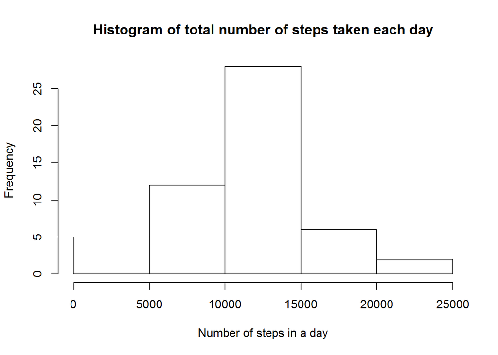

```r
library(dplyr)
stepsByDate <- activity %>% group_by(date) %>% summarise_each(funs(sum(steps)), -interval)
hist(stepsByDate$steps, xlab = "Number of steps in a day", main = "Histogram of total number of steps taken each day")
```

# What is mean total number of steps taken per day?

#### 3.Mean and median number of steps taken each day

```r
library(dplyr)
mean(stepsByDate$steps, na.rm = T)
median(stepsByDate$steps, na.rm = T)
```

```
## [1] 10766.19
## [1] 10765
```

### 4. Timeseries plot of average number of steps taken

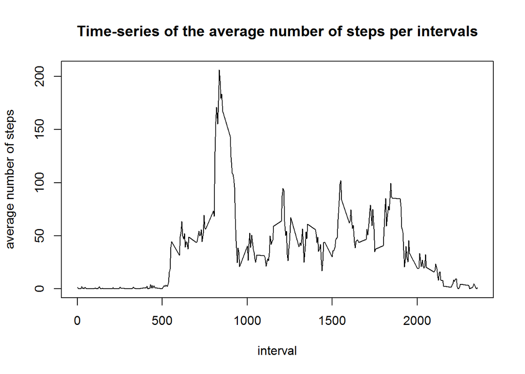

```r
stepsByinterval <- activity %>% group_by(interval) %>% summarise( meanSteps=mean(steps, na.rm=T))
plot(stepsByinterval, type="l", ylab = "average number of steps", main = "Time-series of the average number of steps per intervals")
```

#### 5.The 5-minute interval that, on average, contains the maximum number of steps

```r
stepsByinterval[which.max(stepsByinterval$meanSteps),1]
```

```
## # A tibble: 1 × 1
##   interval
##      <int>
## 1      835
```

# Imputing missing values

#### 6.Code to describe and show a strategy for imputing missing data

```r
sum(complete.cases(activity))
```

```
## [1] 15264
```

we are going to use mean to inpute the missing values by grouping with intervals

```r
activityImputed <- merge(activity,stepsByinterval, by="interval")
activityImputed$steps[is.na(activityImputed$steps)] <- activityImputed$meanSteps[is.na(activityImputed$steps)]
```

#### 7.Histogram of the total number of steps taken each day after missing values are imputed

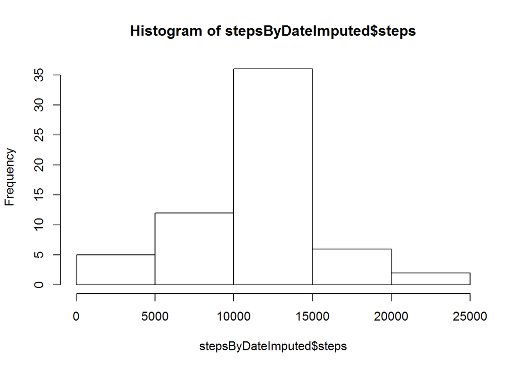

```r
stepsByDateImputed <- activityImputed %>% group_by(date) %>% summarise_each(funs(sum(steps)), -interval)
hist(stepsByDateImputed$steps)
```

mean and median total number of steps taken per day

```r
mean(stepsByDateImputed$steps, na.rm = T)
median(stepsByDateImputed$steps, na.rm = T)
```

```
## [1] 10766.19
## [1] 10766.19
```

# Are there differences in activity patterns between weekdays and weekends?

Inorder to compare between “weekdays” and “weekends” we are going to Create a function to determine weather its a “weekday” or “weekend”

```r
weektype <- function(week){
  if(weekdays(week) %in% c("Saturday", "Sunday")) {
    "Weekend"
    }
  else {
    "Weekday"
    }
}
```

Use the above created function to find if the given day is a “weekday” or “weekend”

```r
activityImputed$week <- as.factor(sapply(activityImputed$date, FUN=weektype))
```

### 8.Panel plot comparing the average number of steps taken per 5-minute interval across weekdays and weekends

```r
stepsByintervalImputed <- activityImputed %>% group_by(week, interval) %>% summarise( meanSteps=mean(steps, na.rm=T))
```

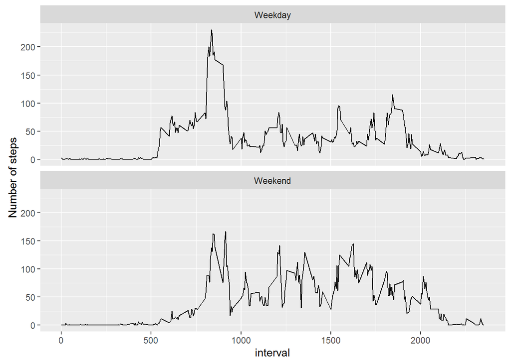

```r
library(ggplot2)
ggplot(data = stepsByintervalImputed, aes(x=interval, y= meanSteps)) + geom_line() + facet_wrap(~week, ncol = 1) + ylab("Number of steps")
```